# TP : Réseaux de neurones graphiques à base d'Attention.

Dans ce TP, nous nous proposons d'étudier le dataset Cora. Celui-ci est composé de 2708 papiers scientifiques répartis en sept classes. L'objectif de ce TP est de construire un modèle permettant de prédire la classe à laquelle appartient un noeud (papier scientifique).

```python
import os
import torch
import networkx as nx
import pandas as pd
import torch.nn.functional as F
from torch_geometric.nn import GATConv
import numpy as np
from sklearn.decomposition import PCA
import matplotlib.pyplot as plt
os.environ['TORCH'] = torch.__version__
print(torch.__version__)

!pip install -q torch-scatter -f https://data.pyg.org/whl/torch-${TORCH}.html
!pip install -q torch-sparse -f https://data.pyg.org/whl/torch-${TORCH}.html
!pip install -q git+https://github.com/pyg-team/pytorch_geometric.git
```

```
2.1.0+cu121
  Installing build dependencies ... done
  Getting requirements to build wheel ... done
  Preparing metadata (pyproject.toml) ... done
```

```python
from torch_geometric.data import Data
from torch_geometric.nn import GATConv
from torch_geometric.datasets import Planetoid
from torch_geometric.utils import to_networkx
import torch_geometric.transforms as T

import matplotlib.pyplot as plt
```

## Analyse du dataset Cora

On se propose ici d'explorer le dataset Cora. Il est fortement recommandé de compléter cette analyse exploratoire (visualiser le graphe, etc.).

```python
dataset = Planetoid(root='~/somewhere/Cora', name='Cora')

data = dataset[0]
print(f'Dataset: {dataset}:')
print('======================')
print(f'Number of graphs: {len(dataset)}')
print(f'Number of features: {dataset.num_features}')
print(f'Number of classes: {dataset.num_classes}')

print(f'Number of nodes: {data.num_nodes}')
print(f'Number of edges: {data.num_edges}')
print(f'Average node degree: {data.num_edges / data.num_nodes:.2f}')
print(f'Number of training nodes: {data.train_mask.sum()}')
print(f'Training node label rate: {int(data.train_mask.sum()) / data.num_nodes:.2f}')
print(f'Contains isolated nodes: {data.contains_isolated_nodes()}')
print(f'Contains self-loops: {data.contains_self_loops()}')
```

```
Dataset: Cora():
======================
Number of graphs: 1
Number of features: 1433
Number of classes: 7
Number of nodes: 2708
Number of edges: 10556
Average node degree: 3.90
Number of training nodes: 140
Training node label rate: 0.05
Contains isolated nodes: False
Contains self-loops: False
```

# Analyse exploratoire et visualisation du dataset Cora

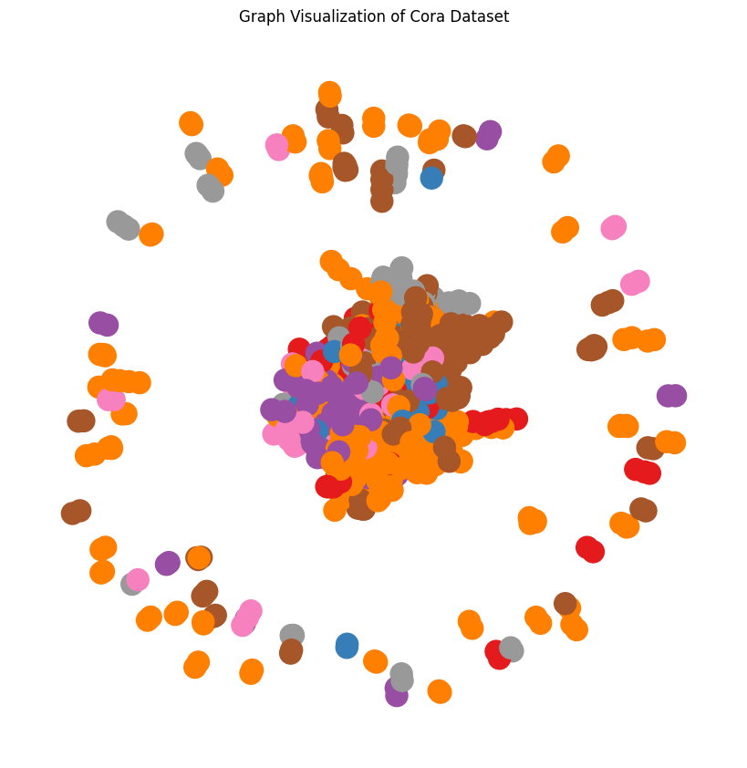

```python
# Convertir les données PyG en un objet NetworkX pour la visualisation
G = to_networkx(data, to_undirected=True)

# Visualisation du graphe
plt.figure(figsize=(8, 8))
pos = nx.spring_layout(G)
colors = data.y.cpu().numpy()
nx.draw(G, pos, node_color=colors, cmap="Set1", with_labels=False)
plt.title('Graph Visualization of Cora Dataset')
plt.show()
```

```python
# Distribution des classes
plt.figure(figsize=(8, 5))
plt.hist(data.y.cpu().numpy(), bins=range(dataset.num_classes + 1), align='left', rwidth=0.8)
plt.xticks(range(dataset.num_classes), [str(i) for i in range(dataset.num_classes)])
plt.xlabel('Class')
plt.ylabel('Number of Nodes')
plt.title('Distribution of Classes in Cora Dataset')
plt.show()
```

[output not shown]

## Construire un modèle à base de GAT qui permet de prédire la classe à laquelle appartient un noeud.

## Visualisation de la Matrice d'Adjacence :

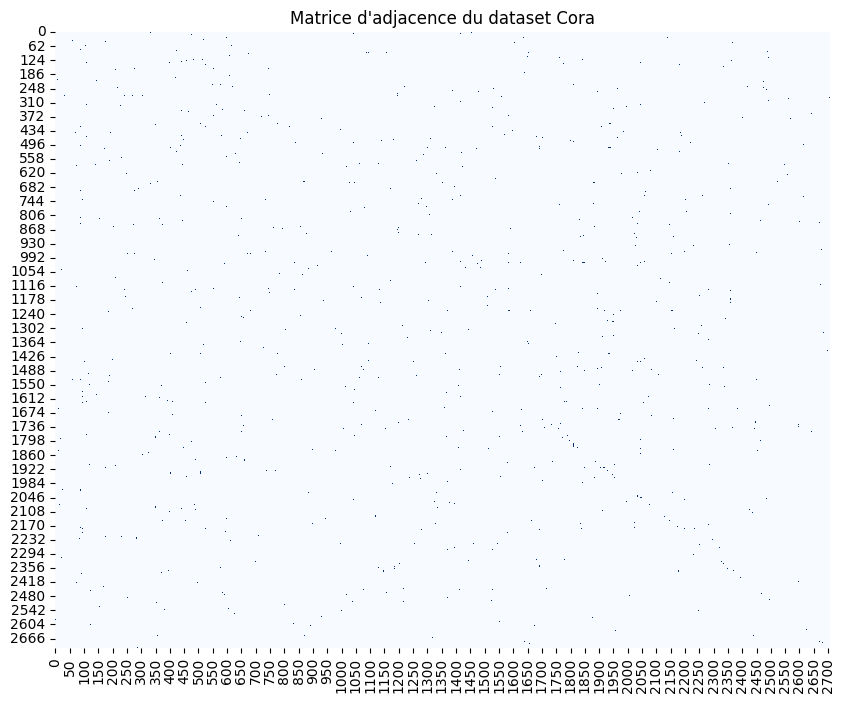

```python
import seaborn as sns

# Convertir le graphe en graphe non dirigé et obtenir la matrice d'adjacence
adjacency_matrix = nx.to_numpy_array(G)

# Créer un DataFrame pour la visualisation
df_adjacency = pd.DataFrame(adjacency_matrix, index=range(data.num_nodes), columns=range(data.num_nodes))

# Afficher la matrice d'adjacence avec heatmap
plt.figure(figsize=(10, 8))
sns.heatmap(df_adjacency, cmap='Blues', cbar=False)
plt.title("Matrice d'adjacence du dataset Cora")
plt.show()
```

## Visualisation avec PCA (2D et 3D) :

Réduit la dimension des caractéristiques avec PCA et visualise le dataset en 2D, puis en 3D.

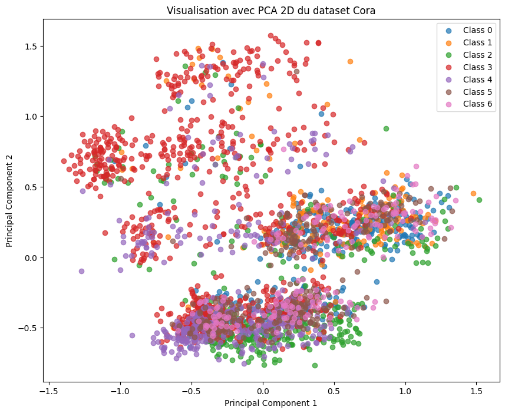

```python
# Récupérer les caractéristiques des nœuds
features = data.x.numpy()

# Appliquer PCA pour réduire la dimension à 2
pca = PCA(n_components=2)
pca_result = pca.fit_transform(features)

# Ajouter les étiquettes de classe aux résultats PCA
pca_result_with_labels = np.column_stack((pca_result, data.y.numpy()))

# Créer un DataFrame pour faciliter la manipulation
df = pd.DataFrame(pca_result_with_labels, columns=['PC1', 'PC2', 'Class'])

# Affichage du nuage de points coloré par classe
plt.figure(figsize=(10, 8))
for class_label in range(dataset.num_classes):
    class_data = df[df['Class'] == class_label]
    plt.scatter(class_data['PC1'], class_data['PC2'], label=f'Class {class_label}', alpha=0.7)

plt.title('Visualisation avec PCA 2D du dataset Cora')
plt.xlabel('Principal Component 1')
plt.ylabel('Principal Component 2')
plt.legend()
plt.show()
```

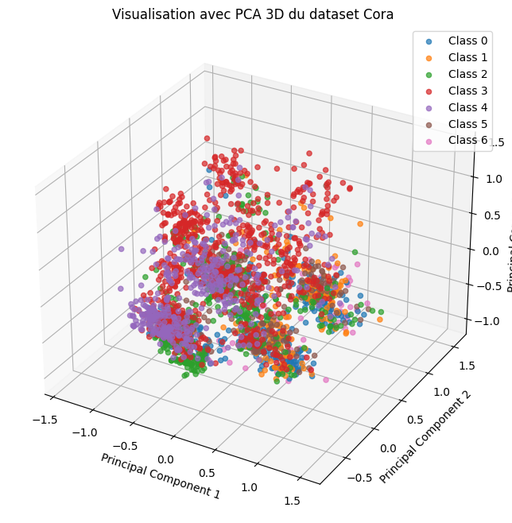

```python
import numpy as np
from sklearn.decomposition import PCA
import matplotlib.pyplot as plt
from mpl_toolkits.mplot3d import Axes3D  # Importer pour la visualisation 3D

# Récupérer les caractéristiques des nœuds
features = data.x.numpy()

# Appliquer PCA pour réduire la dimension à 3
pca = PCA(n_components=3)
pca_result = pca.fit_transform(features)

# Ajouter les étiquettes de classe aux résultats PCA
pca_result_with_labels = np.column_stack((pca_result, data.y.numpy()))

# Créer un DataFrame pour faciliter la manipulation
df = pd.DataFrame(pca_result_with_labels, columns=['PC1', 'PC2', 'PC3', 'Class'])

# Affichage de la visualisation 3D
fig = plt.figure(figsize=(10, 8))
ax = fig.add_subplot(111, projection='3d')

# Scatter plot coloré par classe
for class_label in range(dataset.num_classes):
    class_data = df[df['Class'] == class_label]
    ax.scatter(class_data['PC1'], class_data['PC2'], class_data['PC3'], label=f'Class {class_label}', alpha=0.7)

ax.set_title('Visualisation avec PCA 3D du dataset Cora')
ax.set_xlabel('Principal Component 1')
ax.set_ylabel('Principal Component 2')
ax.set_zlabel('Principal Component 3')
ax.legend()

plt.show()
```

## Modèle GAT (Graph Attention Network) :

Définit une classe de modèle GAT en utilisant la bibliothèque PyTorch Geometric.

```python
class GATModel(torch.nn.Module):
    def __init__(self, num_features, num_classes, num_heads=8):
        super(GATModel, self).__init__()
        self.conv1 = GATConv(num_features, 8, heads=num_heads, dropout=0.25)
        self.conv2 = GATConv(8 * num_heads, 16, heads=num_heads, dropout=0.25)
        self.conv3 = GATConv(16 * num_heads, 32, heads=num_heads, dropout=0.25)

    def forward(self, data):
        x, edge_index = data.x, data.edge_index

        # Première couche GAT avec activation ReLU
        x = F.elu(self.conv1(x, edge_index))
        x = F.dropout(x, p=0.25, training=self.training)

        # Deuxième couche GAT avec activation ReLU
        x = F.elu(self.conv2(x, edge_index))
        x = F.dropout(x, p=0.25, training=self.training)

        # Troixième couche GAT (la dernière) sans activation supplémentaire
        x = self.conv3(x, edge_index)

        return F.log_softmax(x, dim=1)
```

```python
model = GATModel(dataset.num_features, dataset.num_classes, num_heads=8)
criterion = torch.nn.NLLLoss()
optimizer = torch.optim.Adam(model.parameters(), lr=0.005, weight_decay=5e-4)
```

# Entraînement du Modèle GAT

Entraîne le modèle GAT sur le dataset Cora en utilisant la fonction train_model.

```python
def train_model(model, data, epochs=300):
    model.train()
    for epoch in range(epochs):
        optimizer.zero_grad()
        output = model(data)
        loss = criterion(output[data.train_mask], data.y[data.train_mask])
        loss.backward()
        optimizer.step()
        print(f'Epoch {epoch + 1}/{epochs}, Loss: {loss.item():.4f}')

train_model(model, data)
```

[output not shown]

# Évaluation du Modèle GAT

Évalue la précision du modèle GAT sur le jeu de données de test.

```python
def test_model(model, data):
    model.eval()
    output = model(data)
    pred = output.argmax(dim=1)
    correct = pred[data.test_mask] == data.y[data.test_mask]
    acc = correct.sum().item() / data.test_mask.sum().item()
    print(f'Test Accuracy: {acc:.4f}')

test_model(model, data)
```

```
Test Accuracy: 0.7700
```

### Possibles Améliorations :

**1. Équilibrage de la Distribution des Classes :**

La distribution des classes n'est pas équilibrée, ce qui peut affecter la précision du modèle, en particulier pour les classes sous-représentées. Des techniques d'équilibrage de classes telles que l'utilisation de poids de classe, le sur-échantillonnage ou le sous-échantillonnage peuvent améliorer la performance.

**2. Tuning des Hyperparamètres :**

L'ajustement des hyperparamètres peut jouer un rôle crucial dans les performances du modèle. Essayer différentes valeurs pour des paramètres tels que le nombre de têtes d'attention, le taux de dropout, etc., afin d'optimiser les résultats.

**3. Enrichissement des Caractéristiques :**

Ajouter des informations supplémentaires ou des caractéristiques pertinentes au modèle pour renforcer sa capacité à capturer des motifs complexes. Ceci pourrait impliquer l'incorporation de métadonnées ou d'autres données associées aux nœuds.

**4. Ensemble de Modèles :**

Utiliser un ensemble de modèles en combinant plusieurs modèles entraînés de manière indépendante. Cela peut améliorer la robustesse des prédictions en agrégeant la diversité des modèles individuels.

**5. Techniques Avancées de Graph Embedding :**

Explorer des méthodes avancées de représentation de graphe ou d'embedding telles que GraphSAGE, Graph Isomorphism Networks (GIN), ou d'autres architectures de Graph Neural Networks (GNN). Ces approches peuvent fournir des représentations plus riches des structures de graphe.

En mettant en œuvre ces ajustements et en continuant à itérer sur le modèle, il est possible d'améliorer davantage ses performances et sa capacité à généraliser à de nouvelles données.